# MUSA 508, Assignment 1

Zoe Yoo

9/24/2021

### Location

I have decided to study San Francisco for the Transit Indicators assignment. I find it interesting because I used to live just across the bay from San Francisco, and since rents have shot up in the past years, thought it would be relevant to study how that related to transit.

```r
knitr::opts_chunk$set(echo = TRUE)
setwd("C:/Users/zoeny/OneDrive - PennO365/GrSchool/Year1/MUSA 508 Public Policy Analytics/Assignment1")

library(tidyverse)
library(tidycensus)
library(sf)
library(kableExtra)
```

```r
library(ggplot2)
library(dplyr)

source("https://raw.githubusercontent.com/urbanSpatial/Public-Policy-Analytics-Landing/master/functions.r")

options(scipen=999) # telling R to use scientific notation
options(tigris_class = "sf") # tells tidycensus to download Census geometries in the sf or Simple Feature format

mapTheme <- function(base_size = 12) {
  theme(
    text = element_text( color = "black"),
    plot.title = element_text(size = 16,colour = "black"),
    plot.subtitle=element_text(face="italic"),
    plot.caption=element_text(hjust=0),
    axis.ticks = element_blank(),
    panel.background = element_blank(),axis.title = element_blank(),
    axis.text = element_blank(),
    axis.title.x = element_blank(),
    axis.title.y = element_blank(),
    panel.grid.minor = element_blank(),
    panel.border = element_rect(colour = "black", fill=NA, size=2),
    strip.text.x = element_text(size = 14))
}

plotTheme <- function(base_size = 12) {
  theme(
    text = element_text( color = "black"),
    plot.title = element_text(size = 16,colour = "black"),
    plot.subtitle = element_text(face="italic"),
    plot.caption = element_text(hjust=0),
    axis.ticks = element_blank(),
    panel.background = element_blank(),
    panel.grid.major = element_line("grey80", size = 0.1),
    panel.grid.minor = element_blank(),
    panel.border = element_rect(colour = "black", fill=NA, size=2),
    strip.background = element_rect(fill = "grey80", color = "white"),
    strip.text = element_text(size=12),
    axis.title = element_text(size=12),
    axis.text = element_text(size=10),
    plot.background = element_blank(),
    legend.background = element_blank(),
    legend.title = element_text(colour = "black", face = "italic"),
    legend.text = element_text(colour = "black", face = "italic"),
    strip.text.x = element_text(size = 14)
  )
}
# Load Quantile break functions

qBr <- function(df, variable, rnd) {
  if (missing(rnd)) {
    as.character(quantile(round(df[[variable]],0),
                          c(.01,.2,.4,.6,.8), na.rm=T))
  } else if (rnd == FALSE | rnd == F) {
    as.character(formatC(quantile(df[[variable]]), digits = 3),
                 c(.01,.2,.4,.6,.8), na.rm=T)
  }
}
palette5 <- c("#f0f9e8","#bae4bc","#7bccc4","#43a2ca","#0868ac")

q5 <- function(variable) {as.factor(ntile(variable, 5))}
```

### Census Calls

First, I have called census data by tract using the census API for several variables, including total population, number of people who take public transit to work, median household income, median rent, total number of people in poverty, and number of people who have lived in the same house for at least one year. Total population and number of people in poverty are important for, obviously, calculating the percent of low-income people, but median income and median rent are useful for economic analysis, while transit use can be used for both current transit analysis and as an indicator of where more transit may be needed. Lastly, I thought the number of people who have (not) moved in the past year could be a way to look at displacement, but realize that metric cannot say much about such a broad topic on its own, especially due to the limit of just one year.

```r
tracts10 <-
  get_acs(geography = "tract", variables = c("B25026_001E","B08124_022","B15001_050E",
                                             "B15001_009E","B19013_001E","B25058_001E",
                                             "B06012_002E", "B01002_001E", "B07010_012E"),
                year=2010, state=06, county=075, geometry=T, output = "wide") %>%
  st_transform('EPSG:2227') %>%
  rename(TotalPop = B25026_001E,
         PublicTransit = B08124_022E,
         MedHHInc = B19013_001E,
         MedRent = B25058_001E,
         TotalPoverty = B06012_002E,
         MedAge = B01002_001E,
         SameHouse = B07010_012E) %>%
  dplyr::select(-NAME, -starts_with("B")) %>%
  mutate(pctPoverty = ifelse(TotalPop > 0, (TotalPoverty / TotalPop)*100, 0),
         pctSameHouse = ifelse(TotalPop > 0, (SameHouse / TotalPop)*100, 0),
         pctTransit = ifelse(TotalPop > 0, (PublicTransit / TotalPop)*100, 0),
         year = "2010") %>%
  dplyr::select(-TotalPoverty, -SameHouse, -PublicTransit)
tracts10 <- tracts10[-c(47, 97, 197), ] # removing two tracts that have no population (the Farallon islands and another section of water), and Treasure Island

tracts19 <-
  get_acs(geography = "tract", variables = c("B25026_001E","B08124_022","B15001_050E",
                                             "B15001_009E","B19013_001E","B25058_001E",
                                             "B06012_002E", "B01002_001E", "B07010_012E"),
                year=2019, state=06, county=075, geometry=T, output = "wide") %>%
  st_transform('EPSG:2227') %>%
  rename(TotalPop = B25026_001E,
         PublicTransit = B08124_022E, # estimate of people who take public transit to work
         MedHHInc = B19013_001E,
         MedRent = B25058_001E,
         TotalPoverty = B06012_002E,
         MedAge = B01002_001E,
         SameHouse = B07010_012E) %>%
  dplyr::select(-NAME, -starts_with("B")) %>%
  mutate(pctPoverty = ifelse(TotalPop > 0, (TotalPoverty / TotalPop)*100, 0),
         pctSameHouse = ifelse(TotalPop > 0, (SameHouse / TotalPop)*100, 0),
         pctTransit = ifelse(TotalPop > 0, (PublicTransit / TotalPop)*100, 0),
         year = "2019") %>%
  dplyr::select(-TotalPoverty, -SameHouse, -PublicTransit)
tracts19 <- tracts19[-c(60, 96, 197), ] # removing two tracts that have no population (the Farallon islands and another section of water), and Treasure Island
```

Below, I have just mapped out the BART stops to give a basic idea of where major transit lies in San Francisco. San Francisco does have a robust bus system, in addition to streetcars, through the SFMTA, but the number of SFMTA stops is large enough to make visual analysis difficult, so instead stuck to a simpler view of the city’s limited subway.

```r
dd19_5 <- load_variables(year = 2019,dataset = "acs5")

SFtransitStops <-
  rbind(
    # https://data.sfgov.org/Transportation/Muni-Stops/i28k-bkz6 too many stops to incorporate here, and I wasn't able to find data on just rail/streetcar stops
    #st_read("C:/Users/zoeny/OneDrive - PennO365/GrSchool/Year1/MUSA 508 Public Policy Analytics/Assignment1/Muni Stops.geojson") %>%
      # mutate(System = "SF_Muni") %>%
      # select(System),
    # https://www.bart.gov/schedules/developers/geo
    st_read("http://raw.githubusercontent.com/zoenyoo/MUSA508/main/BART_System_2020.geojson") %>%
      mutate(System ="BART") %>%
      select(System)) %>%
  st_transform(st_crs(tracts10))
```

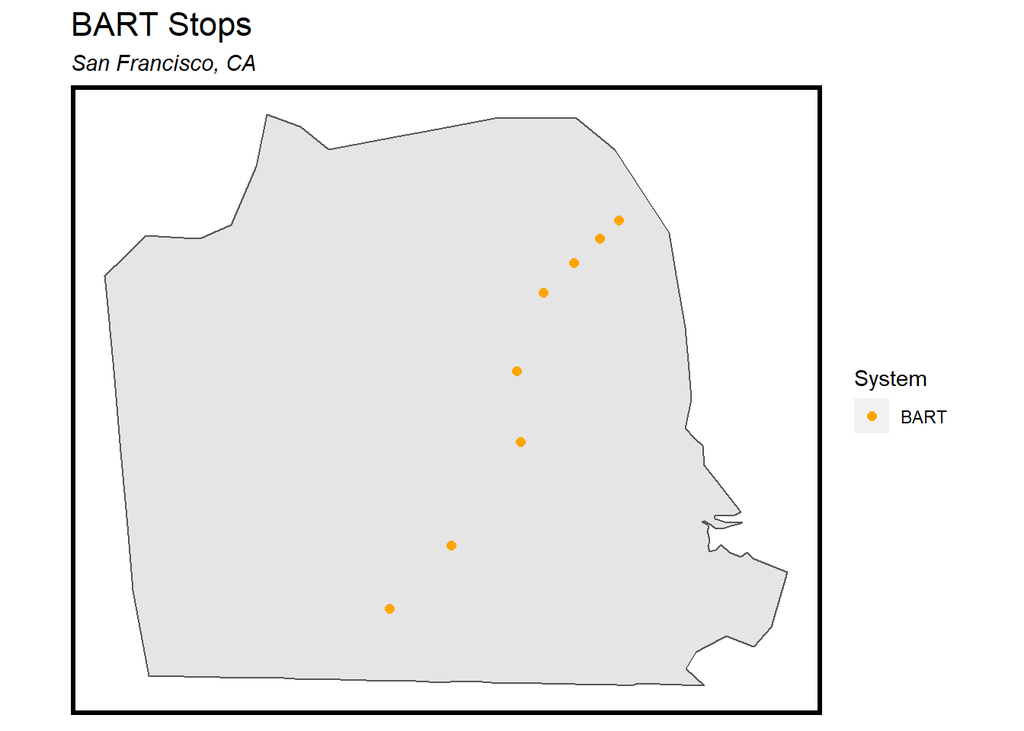

```r
stops_SF <- SFtransitStops[tracts10, ]

ggplot() +
  geom_sf(data=st_union(tracts19)) +
  geom_sf(data=stops_SF,
          aes(colour = System),
          show.legend = "point", size= 2) +
  scale_colour_manual(values = c("orange","blue")) +
  labs(title="BART Stops",
       subtitle="San Francisco, CA",
       ) +
  mapTheme()
```

```r
stop_Buffer <-
  st_union(st_buffer(stops_SF, 2640)) %>%
      st_sf() %>%
      mutate(Legend = "Unioned Buffer")

clip <-
  st_intersection(stop_Buffer, tracts10) %>%
  dplyr::select(TotalPop) %>%
  mutate(Selection_Type = "Clip")

selectCentroids <-
  st_centroid(tracts10)[stop_Buffer,] %>%
    st_drop_geometry() %>%
    left_join(dplyr::select(tracts10, GEOID)) %>%
    st_sf() %>%
    dplyr::select(TotalPop) %>%
    mutate(Selection_Type = "Select by Centroids")
```

### Basic Information

Next, I have made a basic table, as well as bar graphs, of all of the metrics, comparing by both year and proximity to Transit-Oriented Development (TOD). For the purposes of this assignment, TOD was determined by a buffer around BART stations of 0.5 miles, not considering street topography or whether development classified as TOD actually exists inside the buffers. It is mainly to separate walkability versus non-walkability of stations.

```r
allTracts <- rbind(tracts10,tracts19)
allTracts.group <-
  rbind(
    st_centroid(allTracts)[stop_Buffer,] %>%
      st_drop_geometry() %>%
      left_join(allTracts) %>%
      st_sf() %>%
      mutate(TOD = "TOD"),
    st_centroid(allTracts)[stop_Buffer, op = st_disjoint] %>%
      st_drop_geometry() %>%
      left_join(allTracts) %>%
      st_sf() %>%
      mutate(TOD = "Non-TOD")) %>%
  mutate(MedRent.inf = ifelse(year == "2010", MedRent * 1.17, MedRent))
allTracts.Summary <-
  st_drop_geometry(allTracts.group) %>%
    group_by(year, TOD) %>%
    summarize(Rent = mean(MedRent, na.rm = T),
              Population = mean(TotalPop, na.rm = T),
              Percent_Poverty = mean(pctPoverty, na.rm = T),
              Med_Age = mean(MedAge, na.rm = T),
              Percent_Transit = mean(pctTransit, na.rm = T),
              Percent_SameHouse = mean(pctSameHouse, na.rm = T))
kable(allTracts.Summary, digits = 2) %>%
  kable_styling()
```

| year | TOD | Rent | Population | Percent_Poverty | Med_Age | Percent_Transit | Percent_SameHouse |
| --- | --- | --- | --- | --- | --- | --- | --- |
| 2010 | Non-TOD | 1381.82 | 3965.69 | 10.79 | 38.75 | 17.97 | 74.98 |
| 2010 | TOD | 1049.53 | 4059.91 | 20.65 | 40.20 | 21.08 | 76.31 |
| 2019 | Non-TOD | 1934.90 | 4304.93 | 9.70 | 39.56 | 20.77 | 77.38 |
| 2019 | TOD | 1509.56 | 4856.19 | 16.18 | 39.94 | 22.25 | 77.80 |

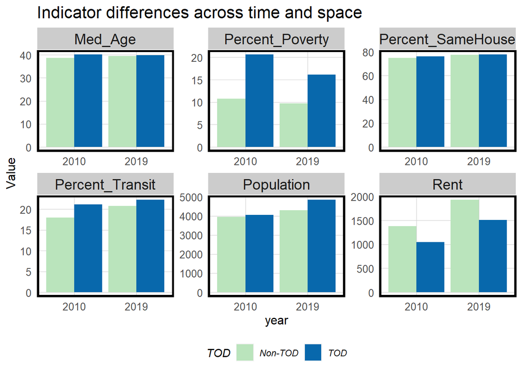

```r
allTracts.Summary %>%
  gather(Variable, Value, -year, -TOD) %>%
  ggplot(aes(year, Value, fill = TOD)) +
    geom_bar(stat = "identity", position = "dodge") +
    facet_wrap(~Variable, scales = "free", ncol=3) +
    scale_fill_manual(values = c("#bae4bc", "#0868ac")) +
    labs(title = "Indicator differences across time and space") +
    plotTheme() + theme(legend.position="bottom")
```

### Indicator Maps

Now, I have spatially mapped each selected indicator, with TOD buffer areas outlined in red.

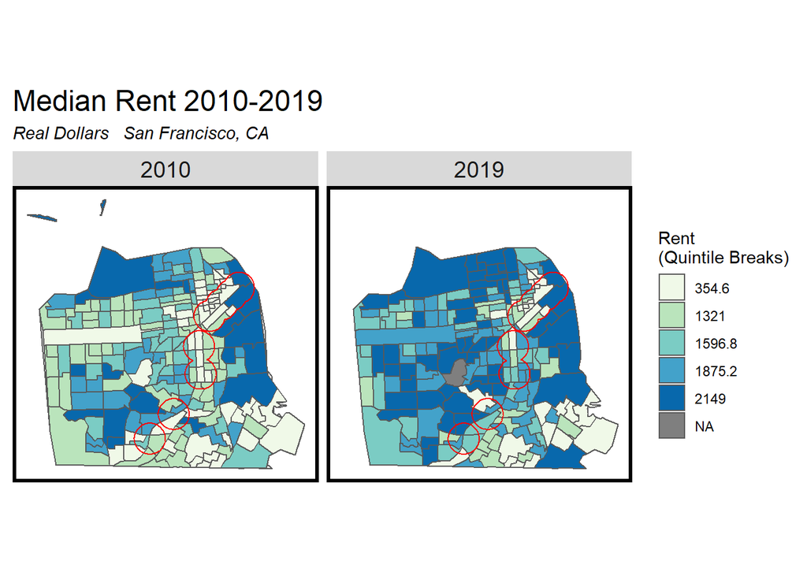

```r
ggplot(allTracts.group)+
    geom_sf(data=st_union(tracts19)) +
    geom_sf(aes(fill = q5(MedRent.inf))) +
    geom_sf(data = stop_Buffer, fill = "transparent", color = "red")+
    scale_fill_manual(values = palette5,
                      labels = qBr(allTracts.group, "MedRent.inf"),
                      name = "Rent\n(Quintile Breaks)") +
    labs(title = "Median Rent 2010-2019", subtitle = "Real Dollars   San Francisco, CA") +
    facet_wrap(~year)+
    mapTheme() +
    theme(plot.title = element_text(size=18))
```

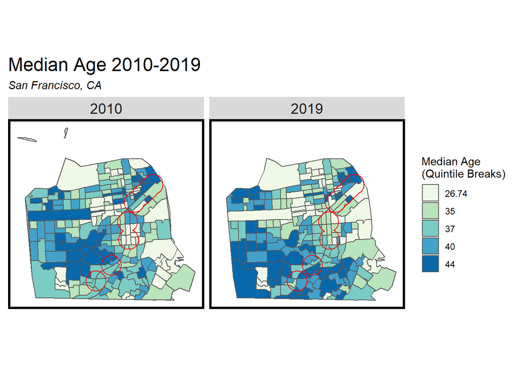

```r
ggplot(allTracts.group)+
    geom_sf(data=st_union(tracts19)) +
    geom_sf(aes(fill = q5(MedAge))) +
    geom_sf(data = stop_Buffer, fill = "transparent", color = "red")+
    scale_fill_manual(values = palette5,
                      labels = qBr(allTracts.group, "MedAge"),
                      name = "Median Age\n(Quintile Breaks)") +
    labs(title = "Median Age 2010-2019", subtitle = "San Francisco, CA") +
    facet_wrap(~year)+
    mapTheme() +
    theme(plot.title = element_text(size=18))
```

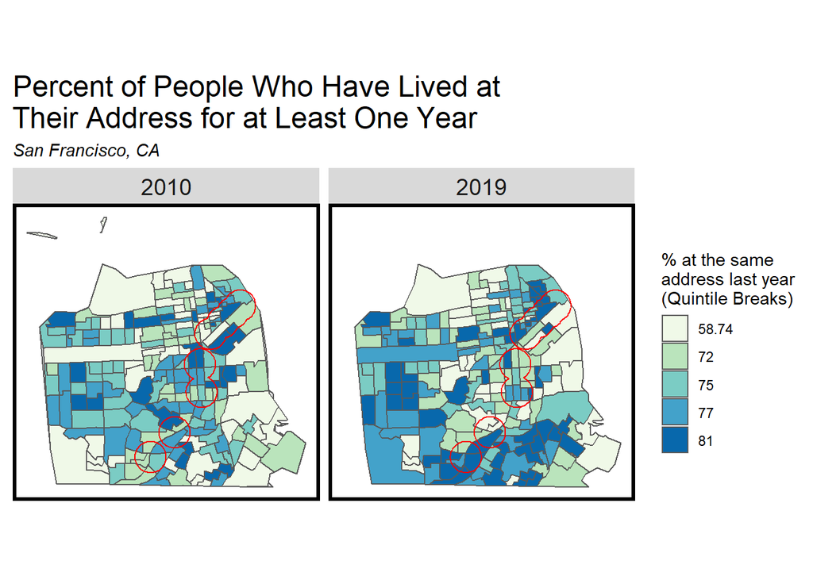

```r
ggplot(allTracts.group)+
    geom_sf(data=st_union(tracts19)) +
    geom_sf(aes(fill = q5(pctSameHouse))) +
    geom_sf(data = stop_Buffer, fill = "transparent", color = "red")+
    scale_fill_manual(values = palette5,
                      labels = qBr(allTracts.group, "pctSameHouse"),
                      name = "% at the same\naddress last year\n(Quintile Breaks)") +
    labs(title = "Percent of People Who Have Lived at \nTheir Address for at Least One Year", subtitle = "San Francisco, CA") +
    facet_wrap(~year)+
    mapTheme() +
    theme(plot.title = element_text(size=18))
```

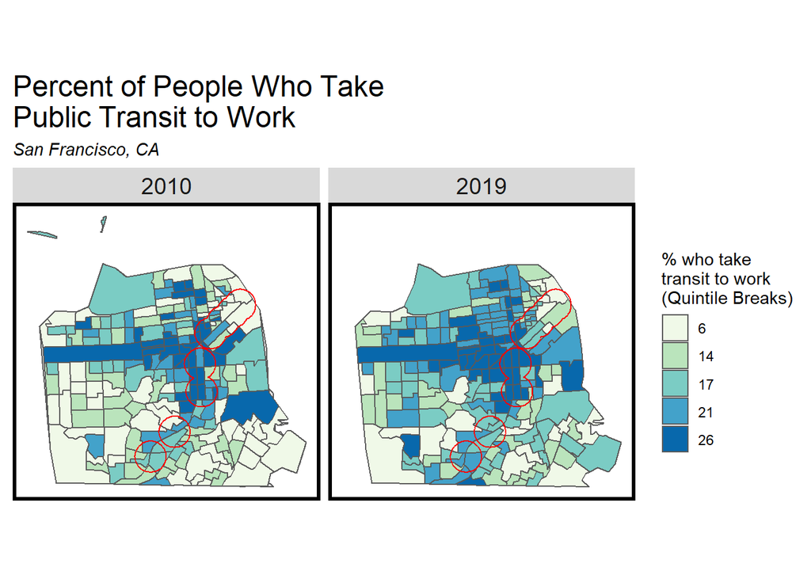

```r
ggplot(allTracts.group)+
    geom_sf(data=st_union(tracts19)) +
    geom_sf(aes(fill = q5(pctTransit))) +
    geom_sf(data = stop_Buffer, fill = "transparent", color = "red")+
    scale_fill_manual(values = palette5,
                      labels = qBr(allTracts.group, "pctTransit"),
                      name = "% who take\ntransit to work \n(Quintile Breaks)") +
    labs(title = "Percent of People Who Take \nPublic Transit to Work", subtitle = "San Francisco, CA") +
    facet_wrap(~year)+
    mapTheme() +
    theme(plot.title = element_text(size=18))
```

### Relationships between Rent and Distance

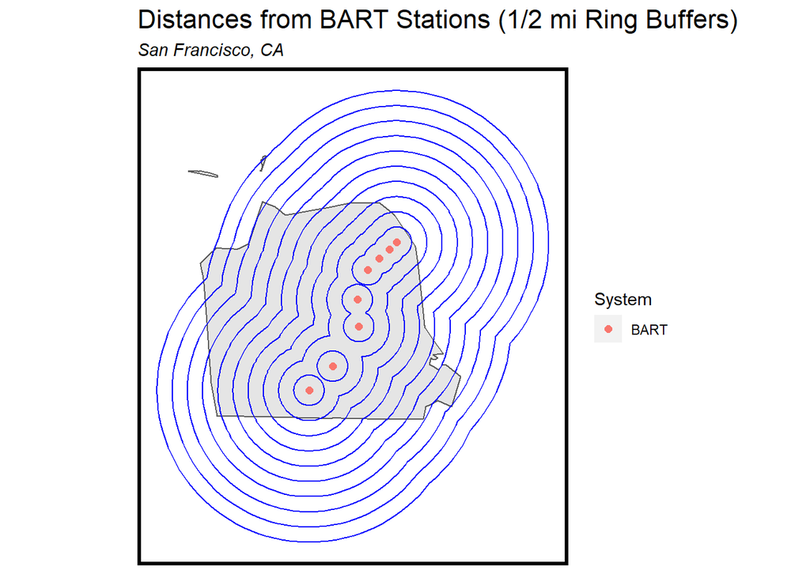

```r
stopBuffers <- rbind(
  st_buffer(stops_SF,2640) %>%
    mutate(Legend = "Buffer") %>%
    dplyr::select(Legend),
  st_union(st_buffer(stops_SF,2640)) %>%
    st_sf() %>%
    mutate(Legend = "Unionized Buffer"),
  st_union(st_buffer(stops_SF,1)) %>%
    st_sf() %>%
    mutate(Legend = "1-foot Buffer")
)

buffer <- filter(stopBuffers, Legend=="Unionized Buffer")
onefoot <- filter(stopBuffers, Legend=="1-foot Buffer")

allTracts.rings <-
  st_join(st_centroid(dplyr::select(allTracts.group, GEOID, year)),
          multipleRingBuffer(onefoot, 26400, 2640)) %>%
  st_drop_geometry() %>%
  left_join(dplyr::select(allTracts.group, GEOID, MedRent, year),
            by=c("GEOID"="GEOID", "year"="year")) %>%
  st_sf() %>%
  mutate(distancef = distance * 1)  %>%
  mutate(distance = distance / 5280)

allTracts.buffrings <-
  multipleRingBuffer(onefoot, 26400, 2640) %>%
  mutate(distance = distance / 5280) #convert to miles


ggplot()+
  geom_sf(data=st_union(tracts10)) +
  geom_sf(data = allTracts.buffrings, fill = "transparent", color = "blue") +
  geom_sf(data=stops_SF,
          aes(colour = System),
          show.legend = "point", size= 2) +
  labs(title = "Distances from BART Stations (1/2 mi Ring Buffers)", subtitle = "San Francisco, CA") +
  mapTheme()
```

```r
AvgRent <-
  allTracts.rings %>%
  group_by(year, distance) %>%
  summarise(Rent = mean(MedRent, na.rm = T))
```

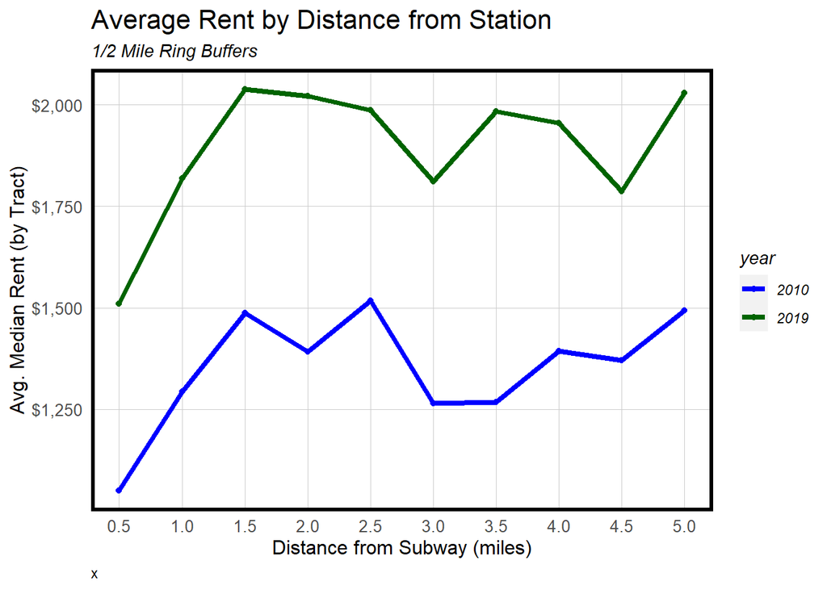

```r
ggplot(data=AvgRent,
       aes(x = distance, y = Rent, color = year)) +
  geom_point() +
  geom_line(size = 1.5) +
  scale_x_continuous(breaks=seq(0, 5, by = 0.5)) +
  scale_color_manual(values = c("blue", "dark green" ))+
  scale_y_continuous(labels = scales::dollar_format()) +
  xlab(label = "Distance from Subway (miles)") +
  ylab(label = "Avg. Median Rent (by Tract)") +
  labs(title = "Average Rent by Distance from Station",
       subtitle = "1/2 Mile Ring Buffers",
       caption ="x") +
  plotTheme()
```

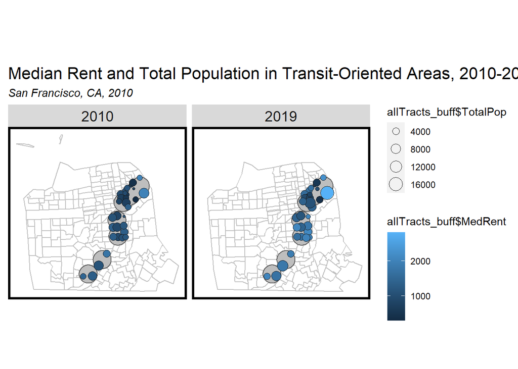

```r
library(RColorBrewer)

allTracts_buff <- st_centroid(allTracts)[stopBuffers,]

graduated_map <- ggplot()+
  #POLYGON BASE
  geom_sf(data = allTracts,
          fill = "white", color = "grey75")+
  geom_sf(data = stop_Buffer, fill = "grey")+
  # POINTS
  geom_sf(data = allTracts_buff %>%
            st_centroid(), # to centroid
          shape = 21, color='grey10',
          aes(
            size = allTracts_buff$TotalPop, # set point size by column value
            fill = allTracts_buff$MedRent # set point fill ('color') by column value
          )) +
  labs(title = "Median Rent and Total Population in Transit-Oriented Areas, 2010-2019", subtitle = "San Francisco, CA, 2010") +
  facet_wrap(~year) +
  mapTheme()

graduated_map
```

```r
#ggplot()+
#  geom_line(data=allTracts, aes(x=allTracts.rings$distance, y=MedRent, group=1))
```

### Crime Data

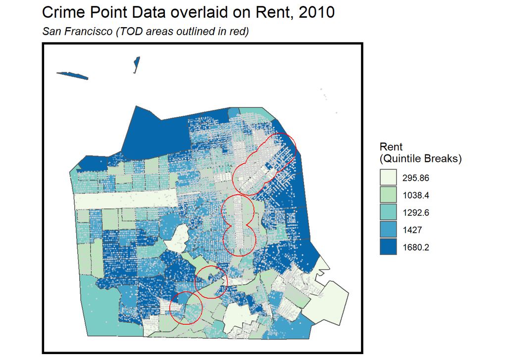

```r
crimePts2010 <-
  read.csv("C:/Users/zoeny/OneDrive - PennO365/GrSchool/Year1/MUSA 508 Public Policy Analytics/Assignment1/Police_Department_Incident_Reports__Historical_2003_to_May_2018.csv", header = TRUE, sep = ",", quote = "\"",
         dec = ".")

crimePts2019 <- read.csv("C:/Users/zoeny/OneDrive - PennO365/GrSchool/Year1/MUSA 508 Public Policy Analytics/Assignment1/Police_Department_Incident_Reports__2018_to_Present.csv", header = TRUE, sep = ",", quote = "\"",
                       dec = ".")

crimePts2010_sf <- st_as_sf(crimePts2010, coords = c("X", "Y"), crs = 4326) %>%
  mutate(Longitude=crimePts2010$X) %>%
  mutate(Latitude=crimePts2010$Y) %>%
  st_transform(st_crs(tracts10))

crimePts2019_sf <- st_as_sf(crimePts2019, coords = c("Longitude", "Latitude"), crs = 4326, agr = "constant")  %>%
  mutate(Longitude=crimePts2019$Longitude) %>%
  mutate(Latitude=crimePts2019$Latitude) %>%
  st_transform(st_crs(tracts10))

# Plot crime and rent for TOD and Non-TOD

ggplot()+
    geom_sf(data=tracts10, aes(fill = q5(tracts10$MedRent))) +
    scale_fill_manual(values = palette5,
                      labels = qBr(tracts10, "MedRent"),
                      name = "Rent\n(Quintile Breaks)")+
    geom_sf(data=crimePts2010_sf,color='lightgrey', size=0.3, alpha=0.25) +
    geom_sf(data = stop_Buffer, fill = "transparent", color = "red") +
    labs(title="Crime Point Data overlaid on Rent, 2010", subtitle="San Francisco (TOD areas outlined in red)") +
    mapTheme()
```

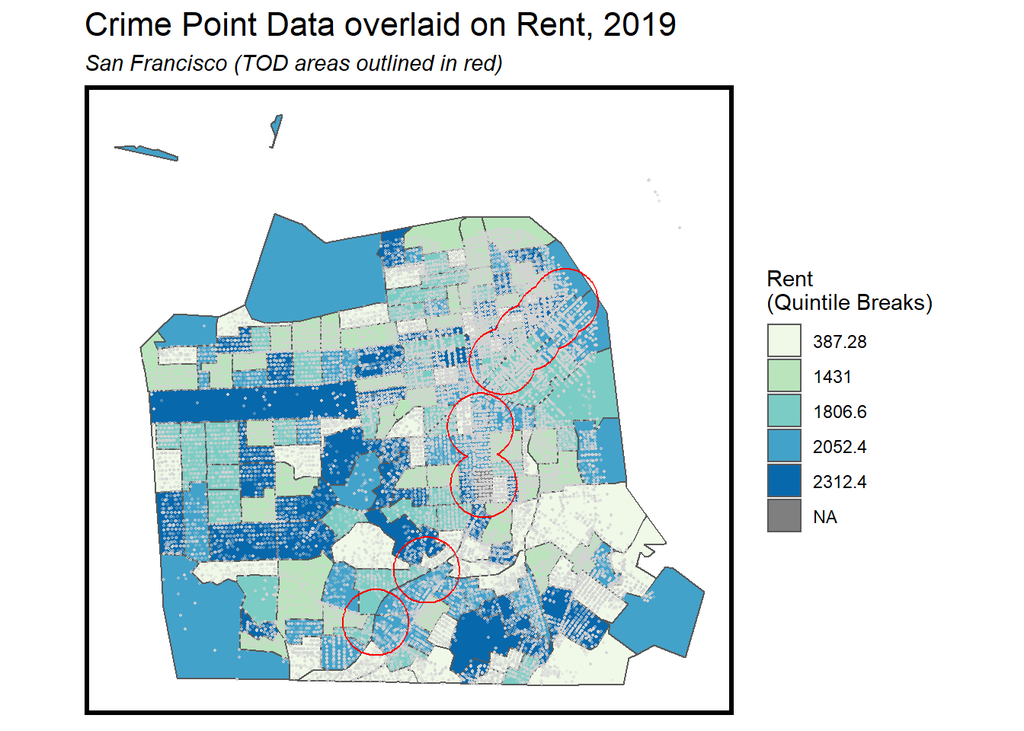

```r
ggplot()+
    geom_sf(data=tracts10, aes(fill = q5(tracts19$MedRent))) +
    scale_fill_manual(values = palette5,
                      labels = qBr(tracts19, "MedRent"),
                      name = "Rent\n(Quintile Breaks)")+
    geom_sf(data=crimePts2010_sf,color='lightgrey', size=0.3, alpha=0.25) +
    geom_sf(data = stop_Buffer, fill = "transparent", color = "red") +
    labs(title="Crime Point Data overlaid on Rent, 2019", subtitle="San Francisco (TOD areas outlined in red)") +
    mapTheme()
```